# **Loan Default Prediction**

# **Milestone**

## **Problem Definition**

### **The Context:**

- Why is this problem important to solve?
- By avoiding loans with high default risk banks can minimize bad debt and loan write offs.
- Improved resource allocation
- Resources can be focused on profitable lenders instead of those that are likely to default.
- Data driven forecasts provide objective insight beyond traditional manual credit scoring reducing bias and human error.
- Accurate prediction models can enable banks to offer more competitive rates and attract more creditworthy customers.

### **The objective:**

- What is the intended goal?
- The goal is to build a classification model that predicts clients likely to default on their home equity loans

### **The key questions:**

- What are the key questions that need to be answered?
- The model should provide interpretable insights into key factors that influence default risk.
- This interpretation helps explain the bank and customer decision making efforts to promote transparency and fairness.
- This project leverages data science and machine learning techniques to develop a classification model capable of predicting the likelihood of a home equity loan default

### **The problem formulation**:

- What is it that we are trying to solve using data science?

The model aims to be:

- High accuracy preventing false positives and negatives ensuring financial security and responsible lending.
- Understanding the key factors influencing predictions increases the transparency and fairness of the decision making process.
- The model must meet The requirements of The Equal Credit Opportunity Act avoiding discriminatory practices based on protected characteristics.
- This problem-frame set the stage for the use of data analysis and modeling techniques to address the loan default prediction challenge.

# **Capstone**

## **Executive Summary**:

**Overview**: Data-driven analytics enable banks to proactively identify risky loans, minimizing bad debt and freeing resources for nurturing profitable relationships. These objective forecasts lead to accurate borrower assessments, allowing for competitive rates and attracting desirable clients, ultimately solidifying financial stability.

**Data and Methodology**:

This report analyzes the Home Mortgage Equity Loan (HMEQ) dataset, encompassing 5,960 loan records. Each record incorporates various attributes relevant to borrower creditworthiness, including loan amount, property value, client occupation, job tenure, and delinquency history. Approximately 20% of the loans exhibited default behavior, signifying the presence of imbalanced class distribution.

**Data Summary**

- Loan Defaults:

  20% of customers default on their loan payments.
- Financial Information:

  Median loan amount: 16,300 dollars Median mortgage due amount: 65,019 Dollars (max: 399,550 Dollars) Median property value: 89,235 Dollars (max: 855,909 Dollars)
- Employment Stability:

  50% of customers have been at their current job for 7 years.
- Loan Delinquency:

  Maximum number of late payments: 10 Maximum number of missed threshold payments: 15
- Credit History:

  Median credit age: 173 months Credit inquiries are uncommon 50% of customers have 20 credit lines Average debt-to-income ratio: 33.77

**Important Findings from Milestone**:

- Data Preprocessing:

  Based on its strong performance and robustness, the tuned decision tree is a suitable candidate for production deployment.

## **Summary of the Problem and Solution**:

Financial institutions face a significant challenge in predicting loan defaults, which can lead to substantial financial losses and hinder business growth. Traditional methods often rely on credit scoring systems susceptible to bias and limitations, potentially leading to inaccurate predictions and missed opportunities. This can result in:

**Increased bad debt**:

- Unforeseen defaults can lead to significant financial losses for institutions.
- Inefficient resource allocation: Resources may be misallocated towards managing risky loans instead of fostering profitable relationships.
- Missed opportunities: Failing to identify creditworthy borrowers can limit growth and profitability.

**Key Points of the Final Solution Design**:

I propose building a machine learning model for loan default prediction using a **Random Forest Classifier algorithm**.

This model offers several advantages:

**Robustness to outliers**:

The Random Forest algorithm is less sensitive to outliers in the data compared to other methods, leading to more reliable predictions.

**Interpretability**:

The Random Forest's structure allows for easy interpretation of the key factors influencing default risk, offering valuable insights for business decision-making.

**Flexibility**:

The model can be easily adapted to incorporate new data or features as needed.

**Reasoning for the Solution Design**:

After evaluating various models, **The Random Forest** emerged as the most effective solution due to:

**Superior performance**:

It achieved a precision and recall 0.92 and 0.83 respectively, significantly outperforming other models like logistic regression, decision tree, tuned decision tree, XGBoost ,XGBoost tuned in this specific case.

**Debt-to-income ratio identified as the most important feature**:

The model highlighted debt-to-income ratio as the most crucial factor influencing default risk, aligning with financial intuition and providing valuable insights into borrower risk assessment.

**Impact on the Problem/Business**:

Implementing this solution is expected to yield significant benefits:

**Reduced bad debt**:

By accurately predicting defaults, the model can help prevent loan losses, potentially saving the institution millions of dollars.

**Improved resource allocation**:

Resources can be redirected towards nurturing profitable relationships with lower-risk borrowers, leading to increased efficiency and profitability.

**Enhanced customer experience**:

Accurate risk evaluation allows for personalized loan offers and better customer service, improving customer satisfaction and loyalty.

**Quantifying the Benefits**:

The specific impact on your business will depend on factors like loan portfolio size, average loan amount, and default rate. However, studies suggest that machine learning models can reduce credit losses by up to 20%. Consider conducting a cost-benefit analysis to estimate the potential financial gains from implementing this solution.

#### **Recommendations for Implementation**:

**Focus on improving recall**: Primary goal is reducing defaults (recall), consider techniques like:

- Cost-sensitive learning: Assign higher weights to  
  misclassified defaulters during training to prioritize their correct prediction.
- Threshold adjustment: Slightly adjust the decision threshold of the model to capture more defaulters, accepting a potential increase in false positives.

**Model interpretability**: Explain how the model makes decisions to gain stakeholder trust and address concerns about fairness. Use feature importance scores and visualizations to highlight key factors influencing predictions.

**Monitoring and updating**:

Regularly track the model's performance on new data and update it periodically to capture changing patterns and maintain accuracy.

#### **Key Actionables for Stakeholders**:

- Management:

  Allocate resources for ongoing monitoring, updates, and potential improvements to the model.
- Loan officers:

  Use the model's predictions to inform lending decisions, considering recall improvements for riskier profiles. Communicate potential limitations and uncertainties of the model.
- Compliance: Ensure the model aligns with regulations and fair lending practices, especially if cost-sensitive learning is used.

#### **Expected Benefits and Costs**:

**Benefits**:

- Reduced loan defaults:

  Improved recall can lead to fewer defaults and lower financial losses.
- Improved risk assessment:

  Data-driven predictions can inform better lending decisions and credit risk management.
- Enhanced customer relationships:

  Proactive measures for potential defaulters can improve customer satisfaction and retention.

**Costs**:

- Model development and deployment: Costs associated with implementing recall-focused improvements.
- Data infrastructure and monitoring: Investment in ongoing data upkeep and model performance tracking.
- Potential false positives: Increased costs due to mistakenly rejecting some good borrowers.

**Quantitative Estimates**:

Baseline default rate: 20% Reduction in default rate due to model: 3%

Average loan size: $16,000 Number of loans issued annually: 10,000 Estimated benefits:

Reduced losses due to defaults: $4.8 million (3% * 16,000 * 10,000) Improved profitability: $4.8 million (reduced losses) + additional benefits (e.g., increased loan volume)

**Estimated costs**:

Model improvements: $10,000 - $20,000 Data management and monitoring: $5,000 - $10,000 annually False positives: Potential costs depending on the extent of misclassification

#### **Key Risks and Challenges**:

-Overfitting:

Model dependence on specific training data, leading to poor performance on new data.

- Data quality: Inaccurate or biased data leading to skewed predictions and unfair outcomes.
- Explainability and interpretability: Difficulty in explaining model decisions, raising concerns about transparency and fairness.
- Regulatory compliance: Ensuring the model adheres to relevant regulations and fair lending practices.

#### **Further Analysis and Associated Problems**:

- Analyze false negatives: Understand why the model misses defaulters to identify potential data or algorithmic biases.
- Assess potential impact on different borrower groups: Ensure fair and unbiased predictions across diverse borrower profiles.
- Develop strategies for managing false positives: Consider mitigation strategies or risk-appropriate actions for borrowers flagged as high-risk.

## **Data Description:**

The Home Equity dataset (HMEQ) contains baseline and loan performance information for 5,960 recent home equity loans. The target (BAD) is a binary variable that indicates whether an applicant has ultimately defaulted or has been severely delinquent. This adverse outcome occurred in 1,189 cases (20 percent). 12 input variables were registered for each applicant.

- **BAD:** 1 = Client defaulted on loan, 0 = loan repaid
- **LOAN:** Amount of loan approved.
- **MORTDUE:** Amount due on the existing mortgage.
- **VALUE:** Current value of the property.
- **REASON:** Reason for the loan request. (HomeImp = home improvement, DebtCon= debt consolidation which means taking out a new loan to pay off other liabilities and consumer debts)
- **JOB:** The type of job that loan applicant has such as manager, self, etc.
- **YOJ:** Years at present job.
- **DEROG:** Number of major derogatory reports (which indicates a serious delinquency or late payments).
- **DELINQ:** Number of delinquent credit lines (a line of credit becomes delinquent when a borrower does not make the minimum required payments 30 to 60 days past the day on which the payments were due).
- **CLAGE:** Age of the oldest credit line in months.
- **NINQ:** Number of recent credit inquiries.
- **CLNO:** Number of existing credit lines.
- **DEBTINC:** Debt-to-income ratio (all your monthly debt payments divided by your gross monthly income. This number is one way lenders measure your ability to manage the monthly payments to repay the money you plan to borrow.

## **Import the necessary libraries and Data**

```python
import pandas as pd
import numpy as np
import matplotlib.pyplot as plt
import seaborn as sns
import sklearn

import warnings
warnings.filterwarnings("ignore")


from sklearn.model_selection import train_test_split
from sklearn.feature_selection import f_classif


# For encoding


from sklearn.preprocessing import LabelEncoder



# Algorithms to use
from sklearn.tree import DecisionTreeClassifier
from sklearn.linear_model import LogisticRegression
from sklearn.tree import DecisionTreeRegressor, DecisionTreeClassifier
from sklearn.impute import SimpleImputer

from sklearn import tree

from sklearn.ensemble import RandomForestClassifier

# Metrics to evaluate the model
from sklearn.metrics import confusion_matrix, classification_report, f1_score
from sklearn.metrics import recall_score
from sklearn.metrics import precision_score
from sklearn.metrics import accuracy_score ,roc_auc_score


from sklearn import metrics

# For hyperparameter tuning
from sklearn.model_selection import GridSearchCV
```

## **Data Overview**

- Reading the dataset
- Understanding the shape of the dataset
- Checking the data types
- Checking for missing values
- Checking for duplicated values

```python
# Read the bank dataset file
data = pd.read_csv('/content/hmeq.csv')
```

```python
from google.colab import drive
drive.mount('/content/drive')
```

```python
# Copying data to another variable to avoid any changes to original data
df = data.copy()
```

```python
# View the first 5 rows of the dataset
df.head()
```

|  | BAD | LOAN | MORTDUE | VALUE | REASON | JOB | YOJ | DEROG | DELINQ | CLAGE | NINQ | CLNO | DEBTINC |
| --- | --- | --- | --- | --- | --- | --- | --- | --- | --- | --- | --- | --- | --- |
| 0 | 1 | 1100 | 25860.0 | 39025.0 | HomeImp | Other | 10.5 | 0.0 | 0.0 | 94.366667 | 1.0 | 9.0 | NaN |
| 1 | 1 | 1300 | 70053.0 | 68400.0 | HomeImp | Other | 7.0 | 0.0 | 2.0 | 121.833333 | 0.0 | 14.0 | NaN |
| 2 | 1 | 1500 | 13500.0 | 16700.0 | HomeImp | Other | 4.0 | 0.0 | 0.0 | 149.466667 | 1.0 | 10.0 | NaN |
| 3 | 1 | 1500 | NaN | NaN | NaN | NaN | NaN | NaN | NaN | NaN | NaN | NaN | NaN |
| 4 | 0 | 1700 | 97800.0 | 112000.0 | HomeImp | Office | 3.0 | 0.0 | 0.0 | 93.333333 | 0.0 | 14.0 | NaN |

```python
# View the last 5 rows of the dataset
df.tail()
```

|  | BAD | LOAN | MORTDUE | VALUE | REASON | JOB | YOJ | DEROG | DELINQ | CLAGE | NINQ | CLNO | DEBTINC |
| --- | --- | --- | --- | --- | --- | --- | --- | --- | --- | --- | --- | --- | --- |
| 5955 | 0 | 88900 | 57264.0 | 90185.0 | DebtCon | Other | 16.0 | 0.0 | 0.0 | 221.808718 | 0.0 | 16.0 | 36.112347 |
| 5956 | 0 | 89000 | 54576.0 | 92937.0 | DebtCon | Other | 16.0 | 0.0 | 0.0 | 208.692070 | 0.0 | 15.0 | 35.859971 |
| 5957 | 0 | 89200 | 54045.0 | 92924.0 | DebtCon | Other | 15.0 | 0.0 | 0.0 | 212.279697 | 0.0 | 15.0 | 35.556590 |
| 5958 | 0 | 89800 | 50370.0 | 91861.0 | DebtCon | Other | 14.0 | 0.0 | 0.0 | 213.892709 | 0.0 | 16.0 | 34.340882 |
| 5959 | 0 | 89900 | 48811.0 | 88934.0 | DebtCon | Other | 15.0 | 0.0 | 0.0 | 219.601002 | 0.0 | 16.0 | 34.571519 |

```python
# Understand the shape of the data
df.shape
```

```
(5960, 13)
```

**Observations:**

- This dataset has 5,960 rows and 13 columns.

```python
# Checking the info of the data
df.info()
```

```
<class 'pandas.core.frame.DataFrame'>
RangeIndex: 5960 entries, 0 to 5959
Data columns (total 13 columns):
 #   Column   Non-Null Count  Dtype
---  ------   --------------  -----
 0   BAD      5960 non-null   int64
 1   LOAN     5960 non-null   int64
 2   MORTDUE  5442 non-null   float64
 3   VALUE    5848 non-null   float64
 4   REASON   5708 non-null   object
 5   JOB      5681 non-null   object
 6   YOJ      5445 non-null   float64
 7   DEROG    5252 non-null   float64
 8   DELINQ   5380 non-null   float64
 9   CLAGE    5652 non-null   float64
 10  NINQ     5450 non-null   float64
 11  CLNO     5738 non-null   float64
 12  DEBTINC  4693 non-null   float64
dtypes: float64(9), int64(2), object(2)
memory usage: 605.4+ KB
```

**Observations:**

- This dataset has 9 float64, 2 int64 and 2 object datatypes.

```python
# Check for missing values in the DataFrame
df.isnull().sum()
```

```
BAD           0
LOAN          0
MORTDUE     518
VALUE       112
REASON      252
JOB         279
YOJ         515
DEROG       708
DELINQ      580
CLAGE       308
NINQ        510
CLNO        222
DEBTINC    1267
dtype: int64
```

```python
df.isnull().sum().sum()
```

```
5271
```

**Observations:**

```python
df.duplicated().sum()
```

```
0
```

**Observations:**

This dataset has no duplicated value

## Summary Statistics

```python
df.describe().T
```

|  | count | mean | std | min | 25% | 50% | 75% | max |
| --- | --- | --- | --- | --- | --- | --- | --- | --- |
| BAD | 5960.0 | 0.199497 | 0.399656 | 0.000000 | 0.000000 | 0.000000 | 0.000000 | 1.000000 |
| LOAN | 5960.0 | 18607.969799 | 11207.480417 | 1100.000000 | 11100.000000 | 16300.000000 | 23300.000000 | 89900.000000 |
| MORTDUE | 5442.0 | 73760.817200 | 44457.609458 | 2063.000000 | 46276.000000 | 65019.000000 | 91488.000000 | 399550.000000 |
| VALUE | 5848.0 | 101776.048741 | 57385.775334 | 8000.000000 | 66075.500000 | 89235.500000 | 119824.250000 | 855909.000000 |
| YOJ | 5445.0 | 8.922268 | 7.573982 | 0.000000 | 3.000000 | 7.000000 | 13.000000 | 41.000000 |
| DEROG | 5252.0 | 0.254570 | 0.846047 | 0.000000 | 0.000000 | 0.000000 | 0.000000 | 10.000000 |
| DELINQ | 5380.0 | 0.449442 | 1.127266 | 0.000000 | 0.000000 | 0.000000 | 0.000000 | 15.000000 |
| CLAGE | 5652.0 | 179.766275 | 85.810092 | 0.000000 | 115.116702 | 173.466667 | 231.562278 | 1168.233561 |
| NINQ | 5450.0 | 1.186055 | 1.728675 | 0.000000 | 0.000000 | 1.000000 | 2.000000 | 17.000000 |
| CLNO | 5738.0 | 21.296096 | 10.138933 | 0.000000 | 15.000000 | 20.000000 | 26.000000 | 71.000000 |
| DEBTINC | 4693.0 | 33.779915 | 8.601746 | 0.524499 | 29.140031 | 34.818262 | 39.003141 | 203.312149 |

**Observations:**

1. Around 20% of customers default on their loan payments.
2. The median loan amount approved is 16,300 dollars.
3. The median mortgage due amount is 65,019 dollars, with a maximum of 399,550 dollars.
4. The median property value is 89,235 dollars, with a maximum of 855,909 dollars.
5. Fifty percent of customers have been at their current job for 7 years.
6. The maximum number of late payments is 10.
7. The maximum number of times a customer missed a threshold payment is 15.
8. Fifty percent of customers have a credit age of 173 months.
9. Credit inquiries are not very common occurrences.
10. Fifty percent of customers have 20 credit lines.
11. The average debt-to-income ratio is 33.77.

```python
# Creating categorical variables
cat_cols = ['REASON','JOB']

for col in cat_cols:
    if col not in data.columns:  # Check for column existence
        print(f"Column '{col}' not found in DataFrame. Skipping...")
        continue

    print(f"\n** Percentage of Subcategories for Column: {col} **")
    print(data[col].value_counts(normalize=True, dropna=False).to_string())  # Include missing values
    print("-" * 70)  # Visual separator
```

```
** Percentage of Subcategories for Column: REASON **
DebtCon    0.659060
HomeImp    0.298658
NaN        0.042282
----------------------------------------------------------------------

** Percentage of Subcategories for Column: JOB **
Other      0.400671
ProfExe    0.214094
Office     0.159060
Mgr        0.128691
NaN        0.046812
Self       0.032383
Sales      0.018289
----------------------------------------------------------------------
```

**Observations:**

- Most loans are for debt consolidation (65.9%) while home improvement makes up nearly 30%.
- Other jobs hold the largest share (40%), followed by professional/executive roles (21.4%).

## **Exploratory Data Analysis (EDA) and Visualization**

- EDA is an important part of any project involving data.
- It is important to investigate and understand the data better before building a model with it.
- A few questions have been mentioned below which will help you approach the analysis in the right manner and generate insights from the data.
- A thorough analysis of the data, in addition to the questions mentioned below, should be done.

**Leading Questions**:

1. What is the range of values for the loan amount variable "LOAN"?
2. How does the distribution of years at present job "YOJ" vary across the dataset?
3. How many unique categories are there in the REASON variable?
4. What is the most common category in the JOB variable?
5. Is there a relationship between the REASON variable and the proportion of applicants who defaulted on their loan?
6. Do applicants who default have a significantly different loan amount compared to those who repay their loan?
7. Is there a correlation between the value of the property and the loan default rate?
8. Do applicants who default have a significantly different mortgage amount compared to those who repay their loan?

### **Univariate Analysis**

```python
# Function to plot a boxplot and a histogram along the same scale


def histogram_boxplot(data, feature, figsize = (12, 7), kde = True, bins = None):

    """
    Boxplot and histogram combined

    data: dataframe
    feature: dataframe column
    figsize: size of figure (default (12, 7))
    kde: whether to the show density curve (default False)
    bins: number of bins for histogram (default None)
    """
    f2, (ax_box2, ax_hist2) = plt.subplots(
        nrows = 2,      # Number of rows of the subplot grid = 2
        sharex = True,  # X-axis will be shared among all subplots
        gridspec_kw = {"height_ratios": (0.25, 0.75)},
        figsize = figsize,

     ) # Creating the 2 subplots
    sns.boxplot(
        data = df, x = feature, ax = ax_box2, showmeans = True, color = "lightgrey"
    )  # Boxplot will be created and a star will indicate the mean value of the column
    sns.histplot(
        data = df, x = feature, kde = kde, ax = ax_hist2, bins = bins, palette = "winter"
    ) if bins else sns.histplot(
        data = df, x = feature, kde = kde, ax = ax_hist2
    )  # For histogram
    ax_hist2.axvline(
        data[feature].mean(), color = "green", linestyle = "--"
    )  # Add mean to the histogram
    ax_hist2.axvline(
        data[feature].median(), color = "black", linestyle = "-"
    )  # Add median to the histogram
    plt.grid(axis='y', linestyle='--', alpha=0.7)  # Add grid lines
    plt.tight_layout()  # Adjust spacing for better visualization
```

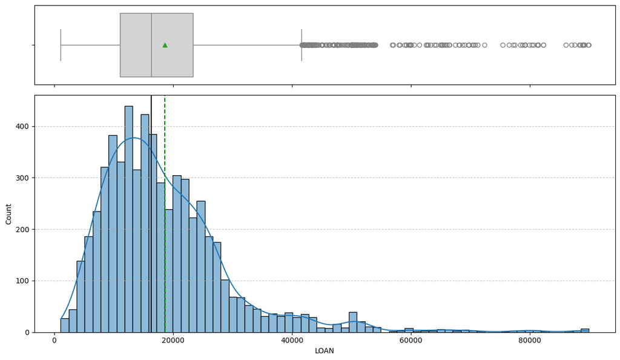

```python
histogram_boxplot(df, 'LOAN')
```

**Observations:**

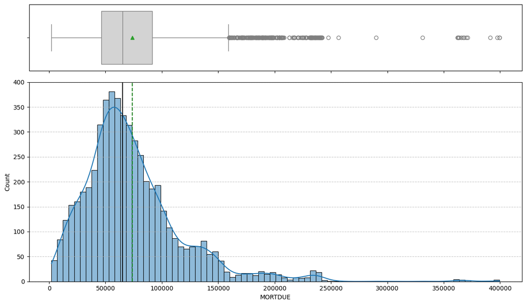

```python
histogram_boxplot(df, 'MORTDUE')
```

**Observations:** 50% of customers have 60,000 dollars due on existing mortgage

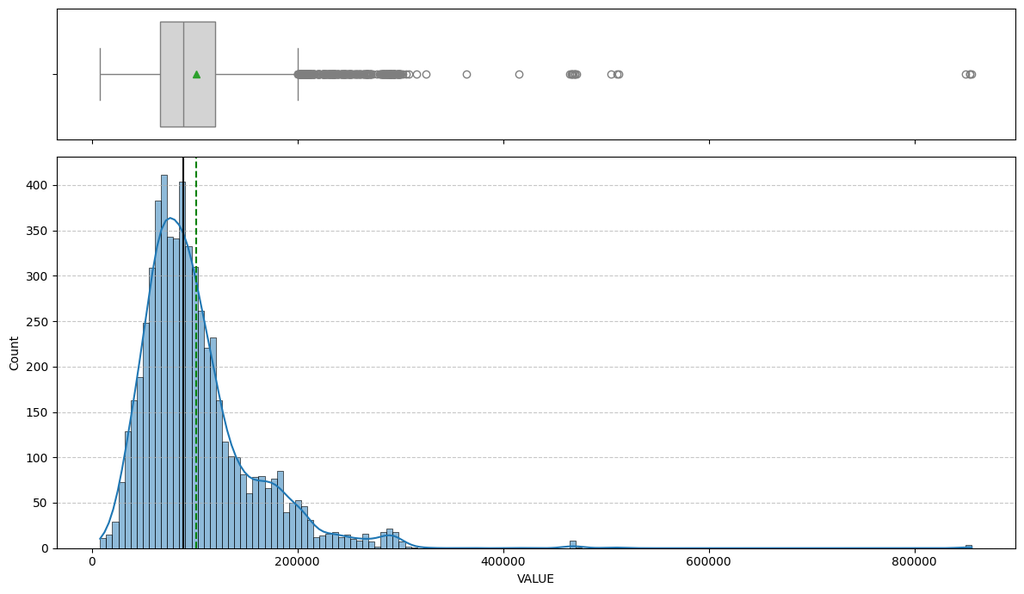

```python
histogram_boxplot(df, 'VALUE')
```

**Observations:** 50% of the customers with properties valued less than $100,000

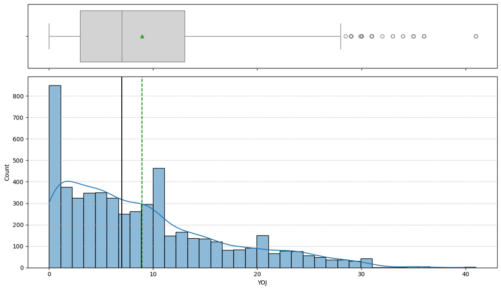

```python
histogram_boxplot(df, 'YOJ')
```

**Observations:**

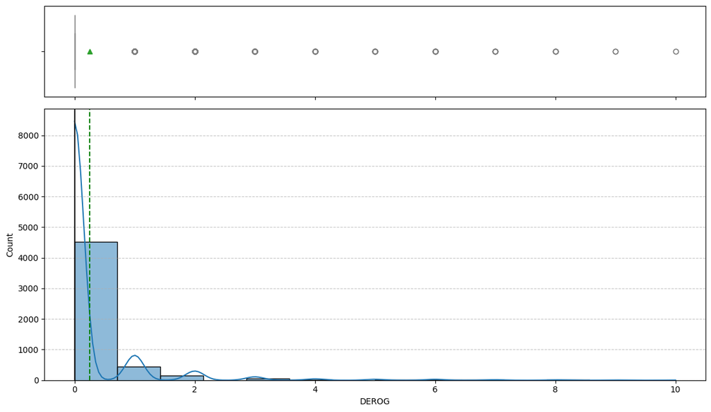

```python
histogram_boxplot(df, 'DEROG')
```

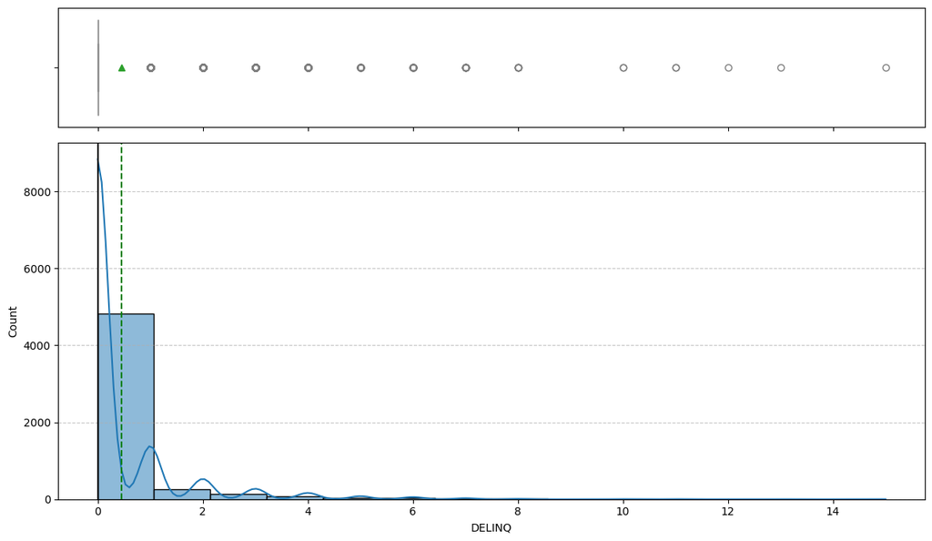

```python
histogram_boxplot(df, 'DELINQ')
```

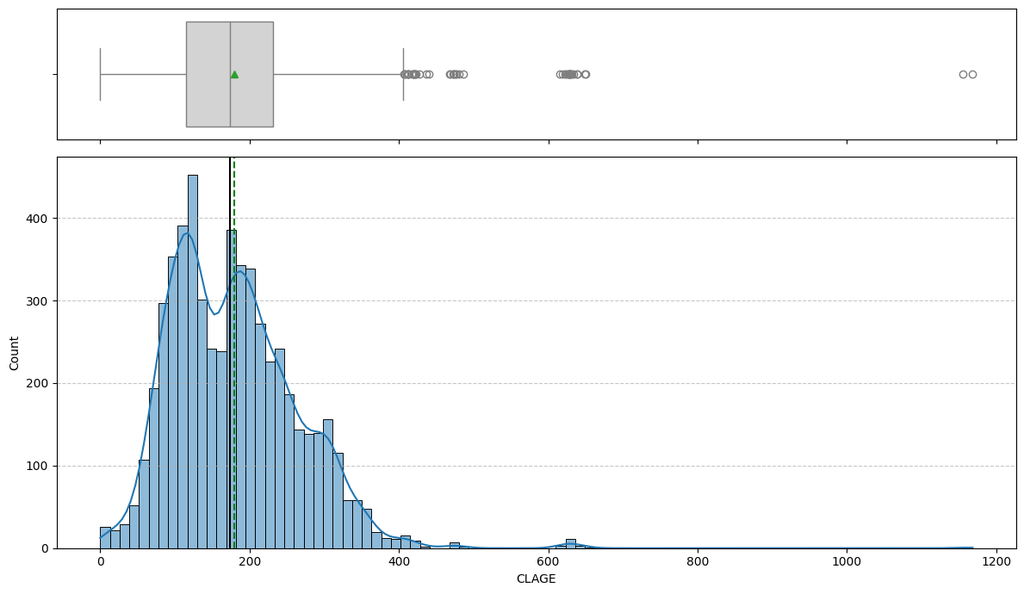

```python
histogram_boxplot(df, 'CLAGE')
```

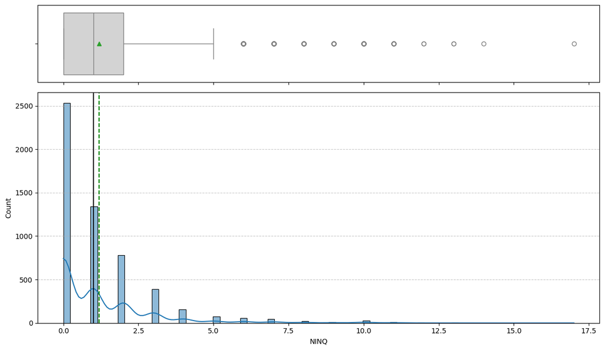

```python
histogram_boxplot(df, 'NINQ')
```

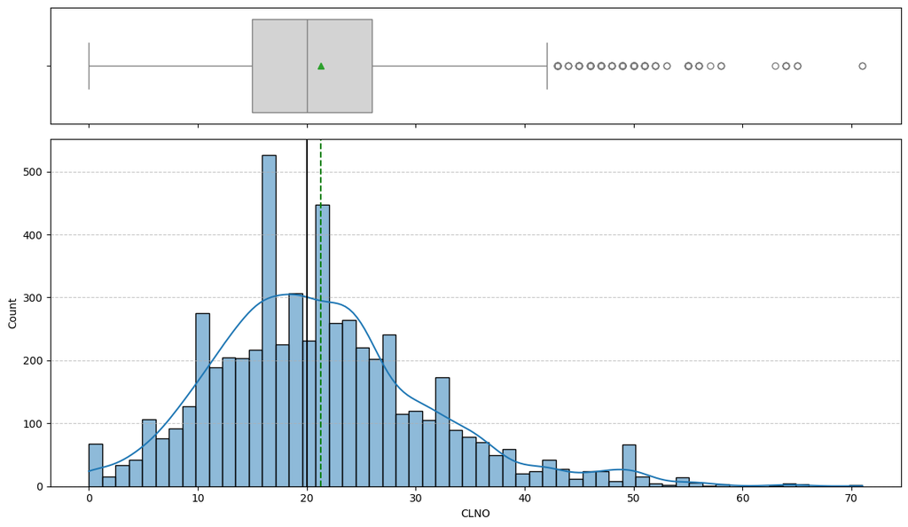

```python
histogram_boxplot(df, 'CLNO')
```

**Observations:** The average number of existing credit lines is 20

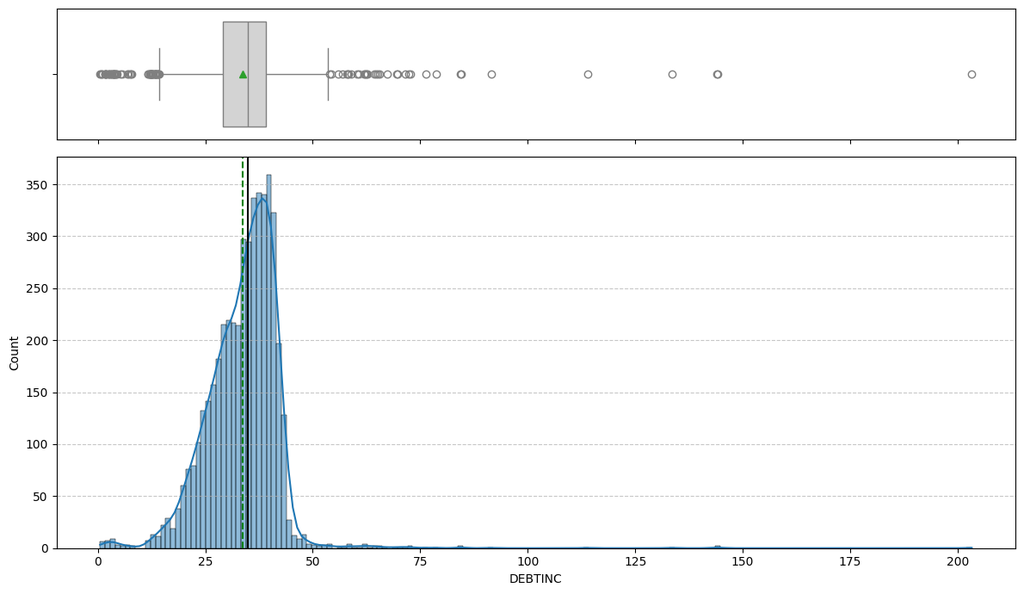

```python
histogram_boxplot(df, 'DEBTINC')
```

```python
def create_bar_plot(data, column_name, title):

    """
    Creates a bar chart for the specified column in the DataFrame,
    with count labels on each bar, and no surrounding black border.

    Args:
        data (pd.DataFrame): The DataFrame containing the data.
        column_name (str): The name of the column to visualize.
        title (str): The title for the plot.
    """

    value_counts = df[column_name].value_counts()  # Get value counts

    plt.figure(figsize=(6, 4))  # Set figure size
    ax = value_counts.plot(kind='bar', color='skyblue', edgecolor='black')  # Create bar chart

    # Remove the top and right spines (borders)
    ax.spines['top'].set_visible(False)
    ax.spines['right'].set_visible(False)

    # Add count labels above each bar
    for p in ax.patches:
        height = p.get_height()
        ax.annotate(f'{height}',  # Format count as string
                    xy=(p.get_x() + p.get_width() / 2, height),  # Center the label
                    xytext=(0, 3),  # Offset text slightly for better readability
                    textcoords='offset points',
                    ha='center', va='bottom')

    plt.title(title)  # Set title
    plt.xlabel(column_name)  # Set x-axis label
    plt.ylabel('Count')  # Set y-axis label
    plt.xticks(rotation=0)  # Rotate x-axis labels for better readability
    plt.grid(axis='y', linestyle='--', alpha=0.7)  # Add grid lines
    plt.tight_layout()  # Adjust spacing for better visualization
    plt.show()  # Display the plot
```

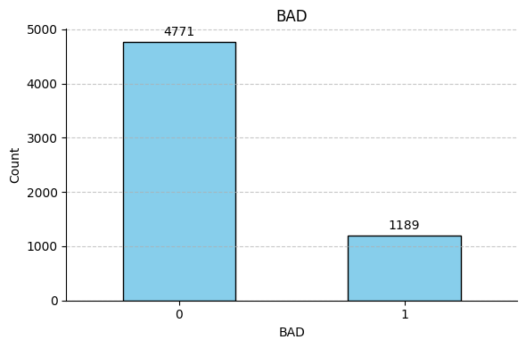

```python
create_bar_plot(df, 'BAD', 'BAD')
```

**Observations:** 1189 defaulted on loan payment

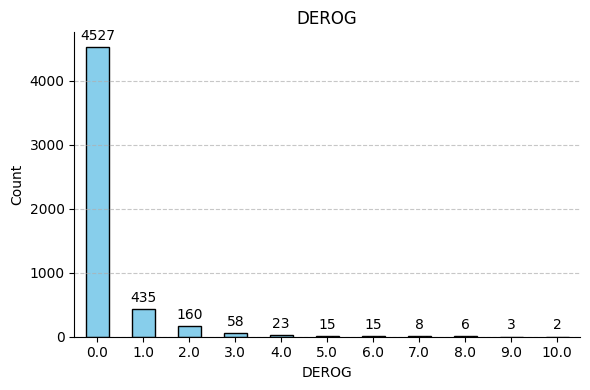

```python
create_bar_plot(df, 'DEROG', 'DEROG')
```

**Observations:** Most of the client don't have derogatory reports

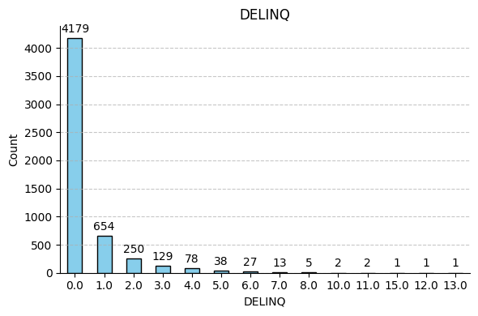

```python
create_bar_plot(df, 'DELINQ', 'DELINQ')
```

**Observations:** Majority of the customers have zero delinquent credit lines

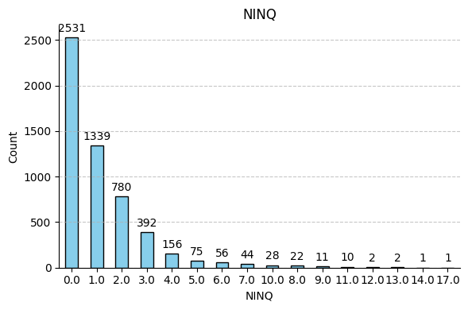

```python
create_bar_plot(df, 'NINQ', 'NINQ')
```

**Observations:** 2531 have zero credit inquiries

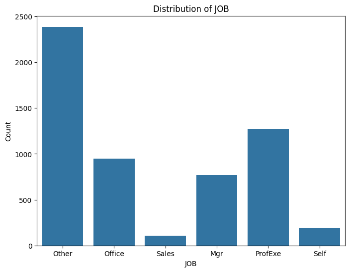

```python
# Creating a countplot for ratings
plt.figure(figsize=(8, 6))
sns.countplot(data=df, x='JOB')
plt.title('Distribution of JOB')
plt.xlabel('JOB')
plt.ylabel('Count')
plt.show()
```

**Observations:** Unspecified or other professionals are majority of the customers, followed by professional executives.

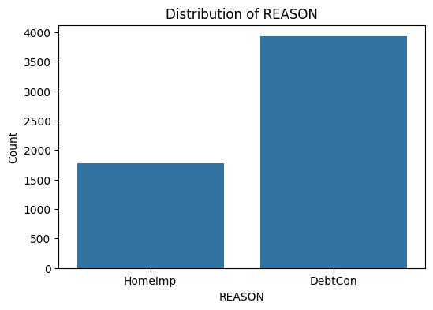

```python
# Creating a countplot for ratings
plt.figure(figsize=(6, 4))
sns.countplot(data=df, x='REASON')
plt.title('Distribution of REASON')
plt.xlabel('REASON')
plt.ylabel('Count')
plt.show()
```

**Observations:** Approximately 4,000 customers use credit loans to pay existing debt.

### **Bivariate Analysis**

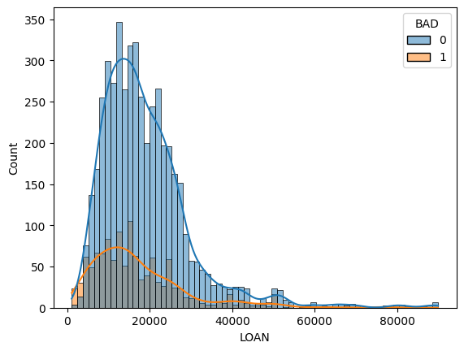

```python
# Assuming 'BAD' is a categorical variable
sns.histplot(data=df, x='LOAN', hue='BAD', kde=True)
```

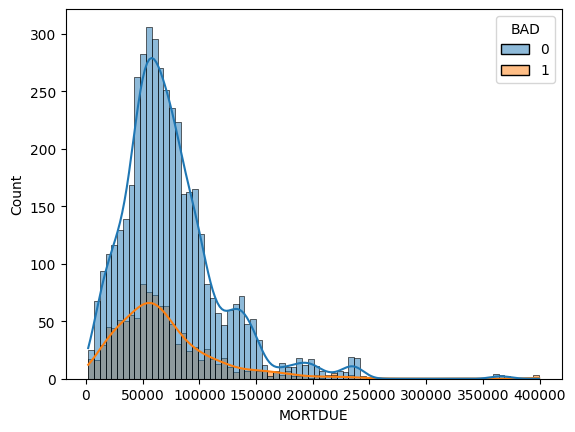

```python
# Assuming 'BAD' is a categorical variable
sns.histplot(data=df, x='MORTDUE', hue='BAD', kde=True)
```

**Observations:** The amount of the mortgage due is consistently unpaid.

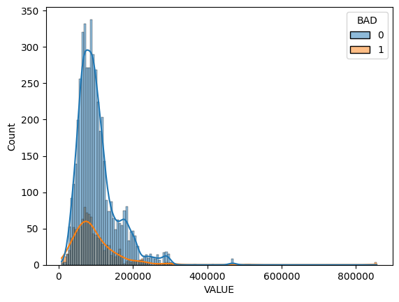

```python
# Assuming 'BAD' is a categorical variable
sns.histplot(data=df, x='VALUE', hue='BAD', kde=True)
```

**Observations:** Inability to pay the loan is independent of the property's value.

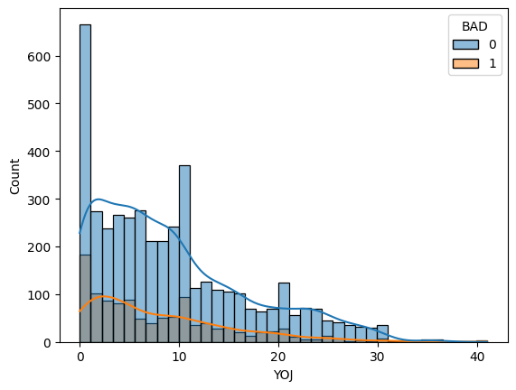

```python
# Assuming 'BAD' is a categorical variable
sns.histplot(data=df, x='YOJ', hue='BAD', kde=True)
```

**Observations:** Years of experience in a particular profession do not directly influence the likelihood of debt default.

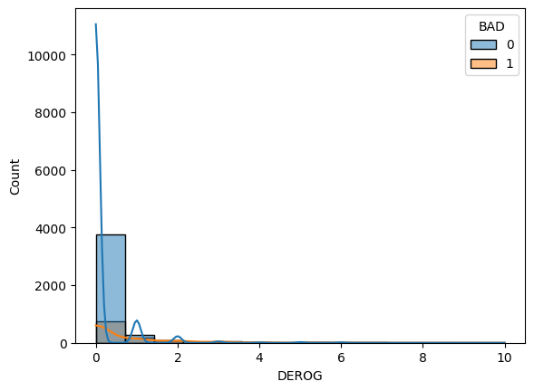

```python
# Assuming 'BAD' is a categorical variable
sns.histplot(data=df, x='DEROG', hue='BAD', kde=True)
```

**Observations:** Having zero major derogatory reports doesn't stop a client default

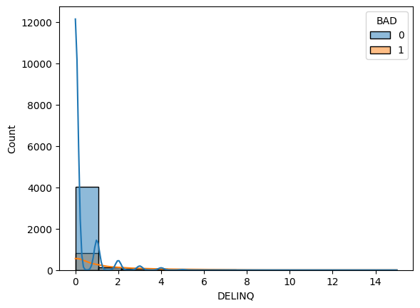

```python
# Assuming 'BAD' is a categorical variable
sns.histplot(data=df, x='DELINQ', hue='BAD', kde=True)
```

**Observations:** Having zero delinquent credit lines on their record doesn't prevent a client from defaulting.

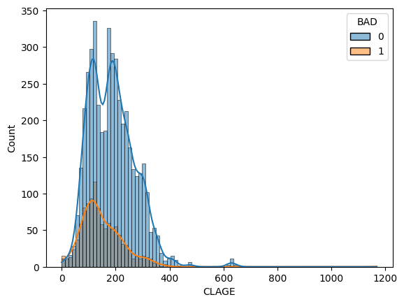

```python
# Assuming 'BAD' is a categorical variable
sns.histplot(data=df, x='CLAGE', hue='BAD', kde=True)
```

**Observations:** Even a long credit history (indicated by the age of the oldest credit line) can't ensure that a client won't default.

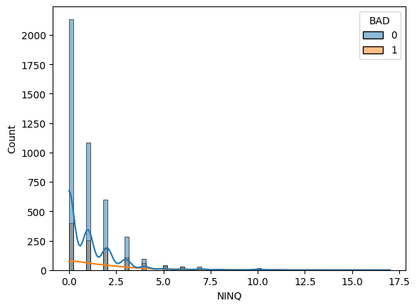

```python
# Assuming 'BAD' is a categorical variable
sns.histplot(data=df, x='NINQ', hue='BAD', kde=True)
```

**Observations:** It's important to note that a high number of recent credit inquiries doesn't automatically translate to client default

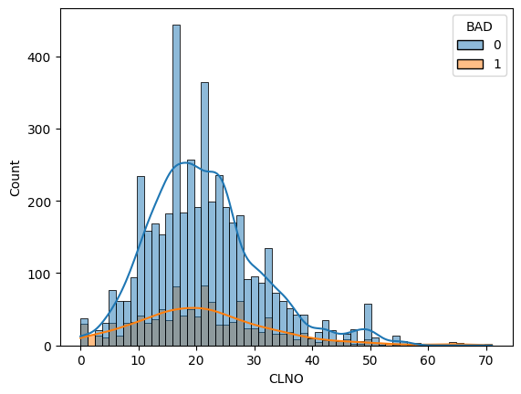

```python
# Assuming 'BAD' is a categorical variable
sns.histplot(data=df, x='CLNO', hue='BAD', kde=True)
```

**Observations:** The presence of multiple existing credit lines does not constitute a definitive deterrent against client default.

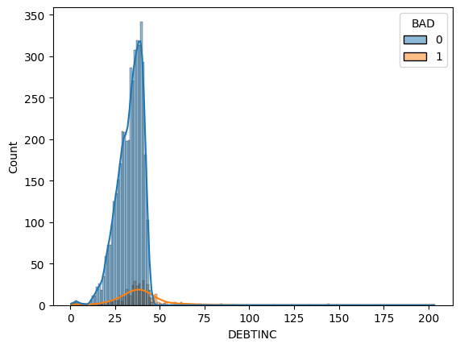

```python
# Assuming 'BAD' is a categorical variable
sns.histplot(data=df, x='DEBTINC', hue='BAD', kde=True)
```

**Observations:** While debt-to-income ratio is an important factor, it doesn't guarantee that a client won't default

```python
def create_countplot_with_hue(data, column_name, title):
    """
    Creates a countplot for the specified column, using 'status' as the hue,
    adds count labels on top of each bar, and removes the surrounding black border.

    Args:
        data (pd.DataFrame): The DataFrame containing the data.
        column_name (str): The name of the column to visualize.
        title (str): The title for the plot.
    """

    plt.figure(figsize=(6, 4))  # Set figure size

    # Use the correct variable for the DataFrame (data, not df)
    ax = sns.countplot(x=column_name, hue='BAD', data=df)  # Create countplot with hue

    # Remove the top and right spines (borders)
    ax.spines['top'].set_visible(False)
    ax.spines['right'].set_visible(False)


    # Add count labels above each bar
    for p in ax.patches:
        height = p.get_height()
        ax.annotate(f'{height}',  # Format count as string
                    xy=(p.get_x() + p.get_width() / 2, height),  # Center the label
                    xytext=(0, 3),  # Offset text slightly for better readability
                    textcoords='offset points',
                    ha='center', va='bottom')


    # Customize the plot (optional)
    plt.title(title)  # Set title based on input parameter
    plt.xlabel(column_name)  # Set x-axis label
    plt.ylabel("Count")  # Set y-axis label
    plt.xticks(rotation=0)  # Rotate x-axis labels for readability
    plt.grid(axis='y', linestyle='--', alpha= 0.7)  # Add grid lines
    plt.tight_layout()  # Adjust spacing

    plt.show()  # Display the plot"""
```

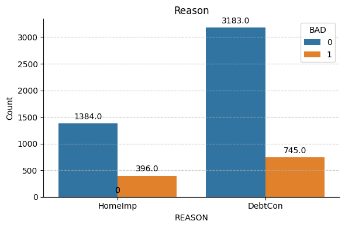

```python
create_countplot_with_hue(df, column_name='REASON', title='Reason'  )
```

**Observations:** Debt consolidation are less likely to default than home improvement

### **Multivariate Analysis**

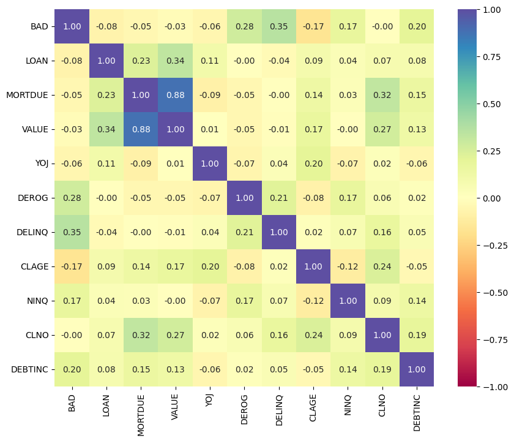

```python
plt.figure(figsize = (10,8))
sns.heatmap(df.corr(), annot = True, vmin = -1, vmax = 1, fmt = ".2f", cmap = "Spectral")
```

**Observations:**

- Most of variables have no relationship
- Value of the property and mortgage due seems to have positive relationship

## Treating Outliers

```python
count_nan = df.isnull().sum()
print(count_nan)  # Shows the number of NaN values in each column
```

```
BAD           0
LOAN          0
MORTDUE     518
VALUE       112
REASON      252
JOB         279
YOJ         515
DEROG       708
DELINQ      580
CLAGE       308
NINQ        510
CLNO        222
DEBTINC    1267
dtype: int64
```

```python
import pandas as pd
from sklearn.preprocessing import OneHotEncoder
from sklearn.model_selection import train_test_split


# Create a separate encoder for each categorical column
encoders = {}
for col in cat_cols:
    if col in df.columns:  # Check if the column exists before encoding
        df[col] = df[col].astype(str)  # Ensure string data type
        encoders[col] = OneHotEncoder(sparse=False)
        X = encoders[col].fit_transform(df[[col]])
        df = pd.concat([df.drop(col, axis=1), pd.DataFrame(X, columns=encoders[col].get_feature_names_out())], axis=1)
    else:
        print(f"Column '{col}' not found in the DataFrame. Skipping encoding.")  # Handle missing columns



# Split data into features (X) and target (y)
X = df.drop('BAD', axis=1)
y = df['BAD']



# Split into training and testing sets
X_train, X_test, y_train, y_test = train_test_split(X, y, test_size=0.3, random_state=1)
```

```python
import pandas as pd



# Function for median imputation
def median_impute(df, columns):
  """
  Imputes missing values (NaNs) with the median for specified columns.

  Args:
    df: The pandas dataframe containing missing values.
    columns: A list of column names to impute with the median.

  Returns:
    A new dataframe with imputed values.
  """
  for col in columns:
    # Impute missing values with median
    df[col].fillna(df[col].median(), inplace=True)
  return df

# Impute NaNs with median for specific columns
imputed_df = median_impute(df.copy(), columns= ['MORTDUE', 'VALUE' ,'YOJ', 'DEROG', 'DELINQ', 'CLAGE', 'NINQ', 'CLNO', 'DEBTINC'])

# Print the results
print(imputed_df)
```

```
      BAD   LOAN  MORTDUE     VALUE   YOJ  DEROG  DELINQ       CLAGE  NINQ  \
0       1   1100  25860.0   39025.0  10.5    0.0     0.0   94.366667   1.0
1       1   1300  70053.0   68400.0   7.0    0.0     2.0  121.833333   0.0
2       1   1500  13500.0   16700.0   4.0    0.0     0.0  149.466667   1.0
3       1   1500  65019.0   89235.5   7.0    0.0     0.0  173.466667   1.0
4       0   1700  97800.0  112000.0   3.0    0.0     0.0   93.333333   0.0
...   ...    ...      ...       ...   ...    ...     ...         ...   ...
5955    0  88900  57264.0   90185.0  16.0    0.0     0.0  221.808718   0.0
5956    0  89000  54576.0   92937.0  16.0    0.0     0.0  208.692070   0.0
5957    0  89200  54045.0   92924.0  15.0    0.0     0.0  212.279697   0.0
5958    0  89800  50370.0   91861.0  14.0    0.0     0.0  213.892709   0.0
5959    0  89900  48811.0   88934.0  15.0    0.0     0.0  219.601002   0.0

      CLNO  ...  REASON_DebtCon  REASON_HomeImp  REASON_nan  JOB_Mgr  \
0      9.0  ...             0.0             1.0         0.0      0.0
```

[output cut: 25 more lines]

```python
# Split data into features (X) and target (y)
X = imputed_df.drop('BAD', axis=1)
y = imputed_df['BAD']



# Split into training and testing sets
X_train, X_test, y_train, y_test = train_test_split(X, y, test_size=0.3, random_state=1)
```

```python
print(imputed_df.isnull().sum())  # Check for remaining missing values
```

```
BAD               0
LOAN              0
MORTDUE           0
VALUE             0
YOJ               0
DEROG             0
DELINQ            0
CLAGE             0
NINQ              0
CLNO              0
DEBTINC           0
REASON_DebtCon    0
REASON_HomeImp    0
REASON_nan        0
JOB_Mgr           0
JOB_Office        0
JOB_Other         0
JOB_ProfExe       0
JOB_Sales         0
JOB_Self          0
JOB_nan           0
dtype: int64
```

## **Important Insights from EDA**

What are the the most important observations and insights from the data based on the EDA performed?

**Observations:**

## **Model Building - Approach**

- Data preparation
- Partition the data into train and test set
- Build the model
- Fit on the train data
- Tune the model
- Test the model on test set

```python
print(X.shape)  # Check the shape of X
print(y.shape)  # Check the shape of y
```

```
(5960, 20)
(5960,)
```

```python
# Creating metric function

def metrics_score(actual, predicted):
    print(classification_report(actual, predicted))

    cm = confusion_matrix(actual, predicted)

    plt.figure(figsize = (8, 5))

    sns.heatmap(cm, annot = True,  fmt = '.2f', xticklabels = ['Paid', 'Default'], yticklabels = ['Paid' ,'Default'])

    plt.ylabel('Actual')

    plt.xlabel('Predicted')

    plt.show()
```

```python
import pandas as pd
from sklearn.metrics import recall_score, precision_score, accuracy_score, f1_score

def model_performance_classification(model, predictors, target):
    """
    Function to compute different metrics to check classification model performance

    model: classifier
    predictors: independent variables
    target: dependent variable
    """

    # Predicting using the independent variables
    pred = model.predict(predictors)

    # Compute metrics
    recall = recall_score(target, pred, average='macro')              # To compute recall
    precision = precision_score(target, pred, average='macro')         # To compute precision
    acc = accuracy_score(target, pred)                                # To compute accuracy score
    f1 = f1_score(target, pred, average='macro')                      # To compute F1-score


    # Create a DataFrame of metrics
    df_perf = pd.DataFrame(
        {
            "Precision": precision,
            "Recall": recall,
            "Accuracy": acc,
            "F1-score": f1,

        },
        index=[1]
    )

    return df_perf
```

### Logistic Regression

```python
X.isna().sum()
```

```
LOAN              0
MORTDUE           0
VALUE             0
YOJ               0
DEROG             0
DELINQ            0
CLAGE             0
NINQ              0
CLNO              0
DEBTINC           0
REASON_DebtCon    0
REASON_HomeImp    0
REASON_nan        0
JOB_Mgr           0
JOB_Office        0
JOB_Other         0
JOB_ProfExe       0
JOB_Sales         0
JOB_Self          0
JOB_nan           0
dtype: int64
```

```python
imputed_df.isna().sum()
```

```
BAD               0
LOAN              0
MORTDUE           0
VALUE             0
YOJ               0
DEROG             0
DELINQ            0
CLAGE             0
NINQ              0
CLNO              0
DEBTINC           0
REASON_DebtCon    0
REASON_HomeImp    0
REASON_nan        0
JOB_Mgr           0
JOB_Office        0
JOB_Other         0
JOB_ProfExe       0
JOB_Sales         0
JOB_Self          0
JOB_nan           0
dtype: int64
```

```python
# Create and train Logistic Regression model
lr = LogisticRegression(class_weight ="balanced", random_state= 1)
lr.fit(X_train, y_train)
```

```
LogisticRegression(class_weight='balanced', random_state=1)
```

```
              precision    recall  f1-score   support

           0       0.89      0.60      0.72      3355
           1       0.30      0.70      0.42       817

    accuracy                           0.62      4172
   macro avg       0.60      0.65      0.57      4172
weighted avg       0.78      0.62      0.66      4172
```

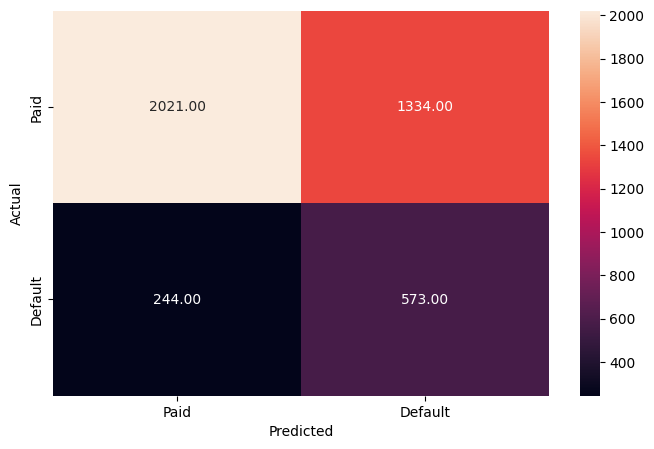

```python
# Checking performance on the training dataset
y_train_pred_lr = lr.predict(X_train)

metrics_score(y_train, y_train_pred_lr)
```

```
              precision    recall  f1-score   support

           0       0.88      0.61      0.72      1416
           1       0.31      0.67      0.43       372

    accuracy                           0.62      1788
   macro avg       0.59      0.64      0.57      1788
weighted avg       0.76      0.62      0.66      1788
```

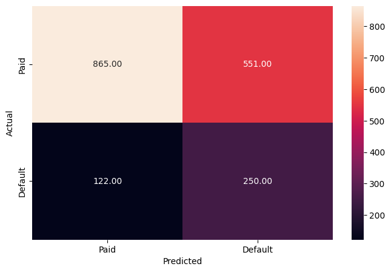

```python
# Checking performance on the test dataset
y_test_pred_lr = lr.predict(X_test)

metrics_score(y_test, y_test_pred_lr)
```

**Observations:**

Logistic regression if giving us the recall of 0.67.

```python
lr_test = model_performance_classification(lr,X_test,y_test)
lr_test
```

|  | Precision | Recall | Accuracy | F1-score |
| --- | --- | --- | --- | --- |
| 1 | 0.594251 | 0.641459 | 0.623602 | 0.573095 |

```python
from sklearn.model_selection import GridSearchCV
from sklearn.linear_model import LogisticRegression

# Define parameter grid
param_grid = {
    'C': [0.001, 0.01, 0.1, 1, 10],
    'solver': ['liblinear', 'lbfgs', 'newton-cg', 'sag'],
    'penalty': ['l1', 'l2']
}

# Create model instance
lr = LogisticRegression()

# Create GridSearchCV object
grid_search = GridSearchCV(estimator=lr, param_grid=param_grid, cv=5)

# Fit the model to the training set
grid_search.fit(X_train, y_train)

# Access best hyperparameters and model
best_params = grid_search.best_params_
best_model = grid_search.best_estimator_
```

```
              precision    recall  f1-score   support

           0       0.85      0.97      0.91      3355
           1       0.75      0.32      0.45       817

    accuracy                           0.85      4172
   macro avg       0.80      0.65      0.68      4172
weighted avg       0.83      0.85      0.82      4172
```

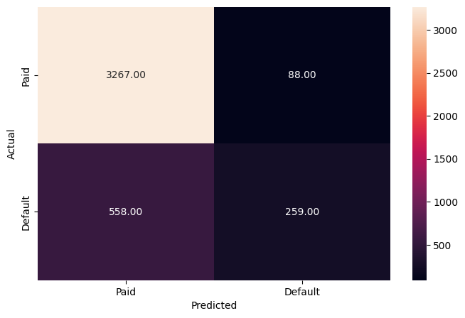

```python
# Checking performance on the training dataset
y_train_pred_lr = grid_search.predict(X_train)

metrics_score(y_train, y_train_pred_lr)
```

```
              precision    recall  f1-score   support

           0       0.84      0.97      0.90      1416
           1       0.71      0.27      0.39       372

    accuracy                           0.83      1788
   macro avg       0.77      0.62      0.65      1788
weighted avg       0.81      0.83      0.79      1788
```

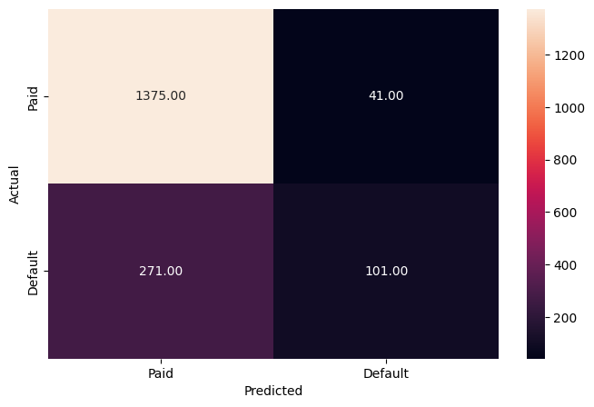

```python
# Checking performance on the training dataset
y_test_pred_lr = grid_search.predict(X_test)

metrics_score(y_test, y_test_pred_lr)
```

```python
lr_metrics_test = model_performance_classification(grid_search,X_test,y_test)
lr_metrics_test
```

|  | Precision | Recall | Accuracy | F1-score |
| --- | --- | --- | --- | --- |
| 1 | 0.773313 | 0.621275 | 0.825503 | 0.645551 |